# Lab Journal: Production of functionalised graphene

# 20171027 GrNH2 production with new diazonium salt

To demonstrate the full experiment of producing Gr-NH<sub>2</sub>, while monitoring the diazonium concentration, a small-scale experiment was conducted with the newly synthesised diazonium salt.

## Journal

A 2 mM solution of 4-aminoethylbenzenediazonium was made by mixing 47 mg with 100 mL 0.1 M H<sub>2</sub>SO<sub>4</sub>. A 1 mM solution of 2-Naphtol was made by mixing 4.3 mg with 6 mL 10 % NaOH and 24 mL H<sub>2</sub>O. This makes it possible to make 4 mL samples for UV-Vis by mixing 3 mL of the 2-Naphtol and 1 mL diazonium-solution.

A 2x6 cm<sup>2</sup> (0.7611 g) piece of graphite foil was used as the anode and a piece of stainless steel as the cathode. 10 V was applied between the electrodes for 85 min. Samples were extracted and temperature and current recorded at regular intervals.

The exfoliated graphene was then washed with copious amounts of water and acetonitrile to remove acid and residual diazonium-salt. In the end the pH of the washing water was approx. 6. The graphene was ultrasonicated in 100 mL DMF for 1 hour and left overnight.

## Results and discussion

```r
library(tidyverse)

data171027 <- tribble(
  ~time, ~temp, ~cur, ~pot,
  0, 22, 1.2, 10,
  10, 38, 1.6, 10,
  20, 48, 1.6, 10,
  40, 60, 1.6, 10,
  60, 61, 1.5, 10,
  85, 58, 1.1, 10
)
```

### UV-Vis

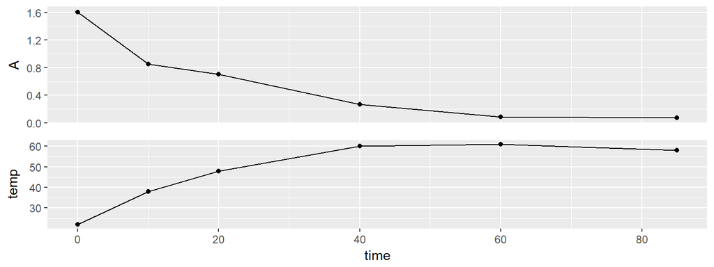

```r
path <- "../data/raw_data/uvvis/20171027_GrNH2_azodye/"
specs171027 <- tibble(file = list.files(path = path, pattern = "*.csv")) %>%
  mutate(data = map(paste0(path,file), read_delim, delim = ";", skip = 1)) %>%
  mutate(time = stringr::str_extract(file, pattern = "\\d{2}(?=min)") %>% as.numeric()) %>%
  unnest()

eps499 = 5.022 # L/cm*mmol
data171027 <- data171027 %>%
  left_join(specs171027) %>%
  mutate(conc = A/eps499 * 4) # Multiplied by 4 to get the diazonium-concentration


g1 <- data171027 %>%
  filter(nm == 499) %>%
  ggplot(aes(time, A)) +
  geom_point() +
  geom_line() +
  theme(axis.text.x = element_blank(), axis.title.x = element_blank(), axis.ticks.x = element_blank())


g2 <- data171027 %>%
  ggplot(aes(time, temp)) +
  geom_point() +
  geom_line()

cowplot::plot_grid(g1, g2, ncol = 1, align = "v")
```

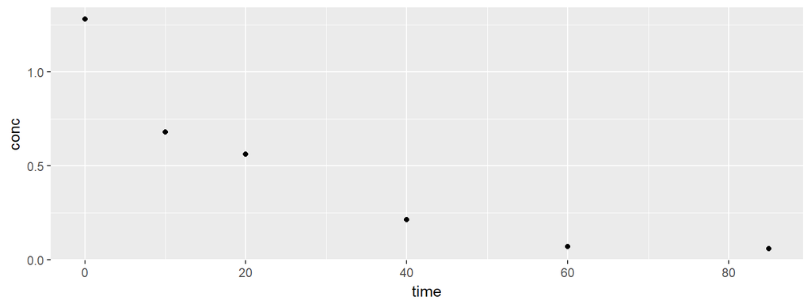

```r
data171027 %>%
  filter(nm == 499) %>%
  ggplot(aes(time, conc)) +
  geom_point()
```

# 20171026 Azodye formation and calibration

Following the succesful synthesis of 4-aminoethylbenzenediazonium salt, it was necessary to repeat azo-dye formation, in order to make a calibration curve for UV-Vis. In this way, the diazonium concentration during graphene exfoliation can easy be monitored by extracting small samples of the electrolyte.

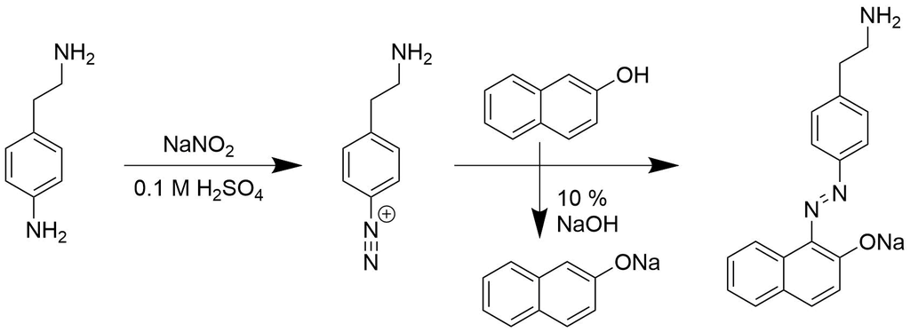

## Journal

Solutions were prepared:

- 2 mM diazonium solution by mixing 14.1 mg in 30 mL 0.1 M H<sub>2</sub>SO<sub>4</sub>
- 3 mM 2-Naphtol solution by mixing 13.0 mg in 6 mL 10 % NaOH and 24 mL H<sub>2</sub>O.

A series of azo samples with different concentrations were prepared, based on the following table:

```r
tribble(
  ~V_diazo, ~V_acid, ~V_naphtol,
  2, 0, 2,
  1, 1, 2,
  0.5, 1.5, 2,
  0.1, 1.9, 2
) %>%
  mutate(
    V_final = V_diazo + V_acid + V_naphtol,
    C_dye = 2 * V_diazo / V_final,
    C_diazo = 2 * C_dye
  ) %>%
  knitr::kable(col.names = c('V~diazo~ (mL)', 'V~H2SO4~ (mL)', 'V~naphtol~ (mL)', 'V~final~ (mL)', 'C~dye~ (mM)', 'C~diazo~ (mM)'))
```

| V<sub>diazo</sub> (mL) | V<sub>H2SO4</sub> (mL) | V<sub>naphtol</sub> (mL) | V<sub>final</sub> (mL) | C<sub>dye</sub> (mM) | C<sub>diazo</sub> (mM) |
| --- | --- | --- | --- | --- | --- |
| 2.0 | 0.0 | 2 | 4 | 1.00 | 2.0 |
| 1.0 | 1.0 | 2 | 4 | 0.50 | 1.0 |
| 0.5 | 1.5 | 2 | 4 | 0.25 | 0.5 |
| 0.1 | 1.9 | 2 | 4 | 0.05 | 0.1 |

This produces bright red dyes immediately upon mixing. Here at 1 mM concentration.

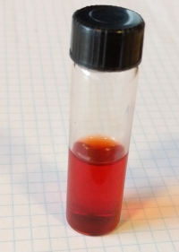

## Results and discussion

```r
path <- "../data/raw_data/uvvis/20171026_Azodye/"
data171026 <- tibble(file = list.files(path = path, pattern = "*.csv")) %>%
  mutate(data = map(paste0(path,file), read_delim, delim = ";", skip = 1)) %>%
  mutate(name = stringr::str_extract(file, pattern = "^[\\sa-zA-Z0-9_-]*")) %>%
  mutate(conc = stringr::str_extract(file, pattern = "[\\d]+\\.[\\d]+(?=mM)") %>% as.numeric()) %>%
  unnest() %>%
  mutate(region = ifelse(nm > 400, "Visible", "UV"))
```

The red dyes have a large absorption, with peaks at 430 nm and 499 nm.

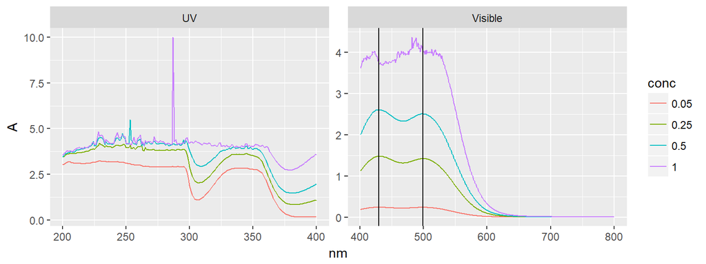

```r
data171026 %>%
  mutate(conc = as.factor(conc)) %>%
  ggplot(aes(nm, A, color = conc)) +
  geom_line() +
  geom_vline(data = tibble(region = "Visible", maxima = c(430, 499)), aes(xintercept = maxima)) +
  facet_wrap(~region, scales = "free")
```

These (here for 499 nm) can be used to calibrate the concentration against the absorption.

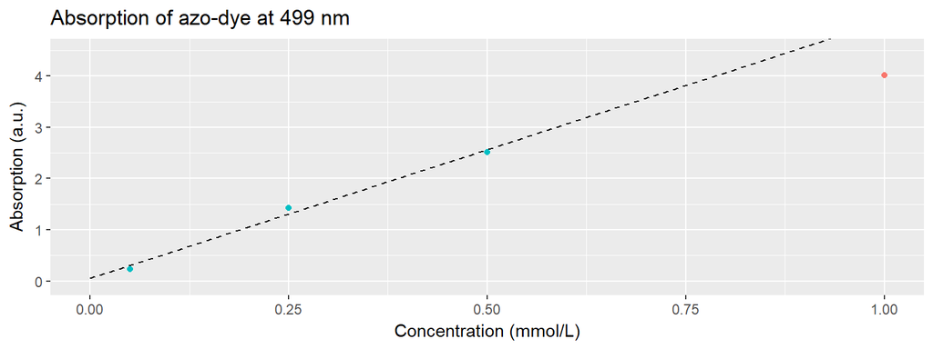

```r
data171026_cal <- data171026 %>%
  filter(nm == 499)

# Fit a linear model to the data
fit171026 <- lm(A ~ conc, data = data171026_cal %>% filter(conc != 1.00))

new_C <- tibble(conc = seq(0, 1, 0.1))
fitted171026 <- cbind(new_C, predict(fit171026, interval = "confidence", newdata = new_C))

eps499 <- round(broom::tidy(fit171026)$estimate[[2]] * 1000) # Extract eps and convert from L/mmol*cm to L/mol*cm

data171026_cal %>%
  ggplot() +
  geom_point(aes(conc, A, color = conc < 1.00)) +
  geom_line(data = fitted171026, aes(conc, fit), linetype = 2) +
  #geom_ribbon(data = fitted171026, aes(x = conc, ymin = lwr, ymax = upr), alpha = 0.2) +
  labs(title = "Absorption of azo-dye at 499 nm", x = "Concentration (mmol/L)", y = "Absorption (a.u.)") +
  theme(legend.position = "none") +
  coord_cartesian(ylim = c(-0.05, 4.5))
```

The 1 mM sample is excluded from this fit, since the sample was too concentrated and the UV-Vis spectrometer could not reliably measure this spectrum. For this reason, the best approach in the exfoliation experiment would be to produce more dilute samples, ensuring that the absorption at 499 nm can be measured reliably.

Using Lambert-Beers law $(A = \epsilon_\lambda\cdot C\cdot l)$, the extinction coefficient of the azo-dye is found to be $\epsilon_{499} = 5022 \frac{L}{cm\, mol}$.

## Conclusion and outlook

This shows the succesful generation of azo-dye molecules, that can be used to monitor the diazonium concentration during exfoliation.

In order to reliably measure the concentration of the extracted samples the concentration needs to be lower (preferably with a dye concentration < 0.5 mM). If exfoliation experiments are still conducted with diazonium-concentration of 2 mM and 2 mL samples are extracted, this means that the volume of the sample for UV-Vis should be $\frac{2\, mM\cdot 2\, mL}{0.5\, mM} = 8 mL$. I wish to use 1.5 eq. of 2-Naphtol, to ensure enough for reaction. This means that the 6 mL 2-Naphtol solution must have a concentration of $\frac{2\, mM\cdot 2\, mL\cdot 1.5}{6\, mL} = 1 mM$. The 2-Naphtol solution used for analysis thus must be a 1 mM solution in $\frac{1}{6}$ 10 % NaOH and $\frac{5}{6}$ H<sub>2</sub>O, which is 0.144 mg/mL.

E.g. for 50 mL solution use 7.2 mg 2-Naphtol in 8 mL 10 % NaOH and 42 mL H<sub>2</sub>O.

# 20171023 Synthesis of 4-(2-aminoethyl)benzenediazonium salt

I have realised, that it is necessary to perfom the synthesis of 4-(2-aminoethyl)benzenediazonium salt to be able to properly control the concentration during exfoliation.

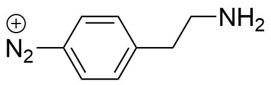

The group (and the literature in general) have many reported strategies for synthesising this compound, however the succes in the group has been varied. Several methods were found in old labbooks and in literature, and a summarised briefly here.

## Protocol: Synthesis of 4-aminoethylbenzenediazonium salt (AEBD)

The synthesis will be conducted according to the procedure from reference.<sup>1</sup> To test the reaction, it will initially be conducted on 100 mg scale.

```r
library(units)
M_aniline = set_units(136.19, mg/mmol)
M_nitrite = set_units(69.00, mg/mmol)
M_diazo = set_units(234.99, mg/mmol) # With BF4-ion
rho_aniline = set_units(1034, mg/mL)

m_aniline = set_units(100, mg)
n_aniline = m_aniline / M_aniline
n_nitrite = n_aniline * 1.5
m_nitrite = n_nitrite * M_nitrite

m_diazo = M_diazo * n_aniline
```

Chemicals: 4-(2-Aminoethyl)aniline ([Sigma](http://www.sigmaaldrich.com/catalog/product/aldrich/123056?lang=en&region=DK), 97 %, 136.19 mg/mmol), Sodium nitrite (Manufacturer? 69 mg/mmol), HBF<sub>4</sub> (Sigma, 48 % in water), diethyl ether (Sigma, >99.8%)

1. 0.75 mL HBF<sub>4</sub> is added to 1.25 mL water and the mixture allowed to cool to 0 $^{\circ}$C.
2. Then 4-(2-aminoethyl)aniline (100 mg, 0.097 mL, 0.73 mmol) is dissolved in the HBF4 solution and allowed to cool to 0 $^{\circ}$C.
3. Sodium nitrite (76 mg, 1.1 mmol) is dissolved in 0.6 mL water and added drop by drop to the acidic amine while stirring.
4. The compounds are reacted for 40 min while keeping the mixture at 0 $^{\circ}$C.
5. A precipitate will appear in the solution and is suction filtrated and rinsed with freezer-cold diethyl ether. The salt is then dried under vacuum (without heating) and stored at -20 $^{\circ}$C.

The product can be characterised by <sup>1</sup>H NMR in deuterated water.

The expected amount of 4-aminoethylbenzenediazonium tetrafluoroborate is 173 mg

## Journal

The synthesis was conducted on 20171025. After addition of 4-(2-aminoethyl)aniline (a yellow oil) to HBF<sub>4</sub> the solution was light yellow. Upon addition of sodium nitrite the solution initially turned orange, and then as the reaction proceeded became milky white, as the precipitate formed.

After washing with 75 mL cold Et<sub>2</sub>O a white-orange powder was collected and dried on the vacuum line.

The empty flask used for drying weighed 13.1772 g. The weight was 13.3899 g after drying. A total of 0.2127 g was formed, corresponding to a yield of 123.3 % (a small amount of product was lost while taking the sample of the vacuum line). This could indicate that the product is not completely pure or dry.

## Results and discussion

<sup>1</sup>H-NMR was obtained of the product. It exhibits peaks which are in agreement with literature values, as well as a small quantity of the starting material (roughly 3.7 %) and a rather large amount of water. The water probably comes from both redisual water in the product and water present in the D<sub>2</sub>O used for NMR.

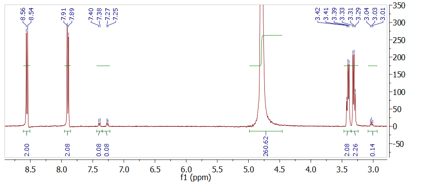

H-NMR of AEBD in D<sub>2</sub>O

However, repeating NMR in CD<sub>3</sub>CN shows that almost no water is present, so the water observed in the first NMR must be from D<sub>2</sub>O. A new impurity is observed at ca. 6.3 ppm, which was not observed previously. I do not expect that this is from my product.

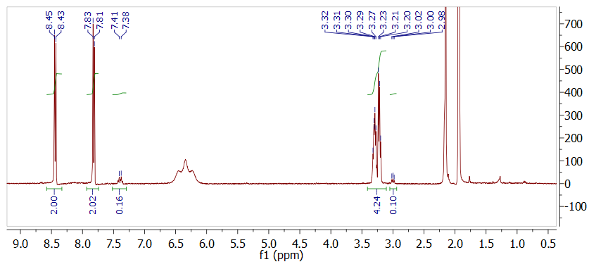

H-NMR of AEBD in CD<sub>3</sub>CN

## Conclusion and outlook

The synthesis of 4-aminoethylbenzenediazonium salt was easy and a high-purity product in decent yield was obtained. This procedure should be easy to scale up, in order to synthesise several grams for graphene functionalisation.

# 20171020 Gr-NH2 production repeated

This experiment is a repetition of 20170929, as several aspects of the experiment failed to work as expected. By a few simple modifications, it will hopefully be possible to 1) monitor diazonium concentration, and 2) obtain a proper freeze-dried product.

## Protocol

```r
library(units)
V = set_units(1500, mL) # Volume of 0.1 M H2SO4 to be used
C_diazo = set_units(2, mmol/L)
C_naphtol = set_units(3, mmol/L)
V_naphtol = set_units(30, mL)

M_nitro = set_units(202.64, mg/mmol) # 4-Nitrophenethylamine hydrochloride
M_nitrite = set_units(69.00, mg/mmol) # NaNO2
M_naphtol = set_units(144.17, mg/mmol) # 2-Naphtol

n_nitro = V * C_diazo
n_nitrite = n_nitro * 2
n_naphtol = V_naphtol * C_naphtol # enough to make 15 samples of 2 mL

m_nitro = n_nitro * M_nitro
m_nitrite = n_nitrite * M_nitrite
m_naphtol = n_naphtol * M_naphtol

C_dye = set_units(C_diazo * set_units(2, mL) / set_units(4, mL), mmol/L)
```

### Preparing solutions

150 mL 1.0 M H<sub>2</sub>SO<sub>4</sub> is diluted to 1500 mL to produce 0.1 M H<sub>2</sub>SO<sub>4</sub>.

The 2 mmol/L 4-(2-aminoethyl)benzenediazonium solution is generated *in-situ* by mixing 1500 mL 0.1 M H<sub>2</sub>SO<sub>4</sub> with 607.92 mg 4-Nitrophenethylamine hydrochloride (3 mmol) and 414 mg NaNO<sub>2</sub> (6 mmol). This is stirred for 15 min.

A 3 mmol/L solution of 2-Naphtol is made by dissolving 12.9753 mg mg 2-Naphtol in 6 mL 10 % NaOH and 24 mL H<sub>2</sub>O.

Samples for UV-Vis can then be made easily by mixing 2 mL 3 mmol/L 2-Naphtol solution with 2 mL 2 mmol/L diazonium-solution to obtain a solution of the azo-dye (max conc. obtained is 1 mmol/L).

### Gr-NH<sub>2</sub> exfoliation

The electrochemical exfoliation of functionalised graphene will be done by positioning and 8x15 cm<sup>2</sup> graphite foil between two large stainless steel electrodes and applying 10 V for 1 hour or more. Weigh the foil before electrolysis.

2 mL samples will be extracted with a syringe and put into the 2-Naphtol solution through a filter (to remove any graphite) every 20 minutes. At these points the temperature should also be noted. The samples are put in a 50 Â°C water bath for 2 minutes to facilitate reaction, before measuring the UV-Vis absorption.

The exfoliated graphene and remaining graphite foil is collected and washed several times with water (mix thoroughly with water, measure pH of the filtrate). Keep most of the graphene at this point and work from here only in smaller batches to test the freeze-drying procedure.

The graphene is ultrasonicated in DMF (perhaps ca. 1 g / 100 mL) and left overnight for graphite to sediment.

The upper 95 % of the solution is collected and centrifuged to collect most of the graphene. It is then ultrasonicated in water and freeze-dried.

## Journal

The graphene was exfoliated as described in the protocol. Before exfoliation, graphite was expanded by submersing in liquid nitrogen for 30 s, followed by immersion in ethanol. This makes the foil expand to ~4 times the thickness. It was noted, however, that the current recorded was not significantly higher than previous experiments, meaning that the exfoliation might be diffusion-limited at this point.

The graphite foil weighed 7.07 g prior to exfoliation.

Samples for UV-Vis were extracted every 20 min. At 80 min a new solution of diazonium-salt was made (although not with super accurate amounts, and probably let to react for too short time) to test the whether the 2-Naphtol solution was still active. Similarly, at 100 min a fresh 2-Naphtol solution was made to test properly for the final diazonium concentration.

The exfoliated graphite was repeatedly washed with water (500 mL, completely mixing graphite and water) and filtrated until the pH was ca. 6. The collected graphene was then exfoliated by ultrasonication in 300 mL DMF for 60 min.

## Results and discussion

```r
data171020 <- read_csv('../data/raw_data/electrochemistry/20171020_Gr-NH2_exfoliation.csv')
knitr::kable(data171020, col.names = c("Time (min)", "Temp. ($^{\\circ}$C)", "Voltage (V)", "Current (A)"))
```

| Time (min) | Temp. ($^{\circ}$C) | Voltage (V) | Current (A) |
| --- | --- | --- | --- |
| 0 | 24 | 10 | 15.5 |
| 20 | 36 | 10 | 18.8 |
| 40 | 54 | 10 | 19.3 |
| 60 | 67 | 10 | 19.3 |
| 80 | 73 | 10 | 18.4 |
| 100 | 73 | 10 | 14.3 |

### UV-Vis

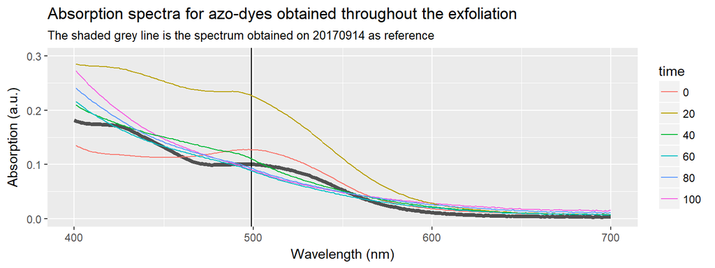

```r
path <- "../data/raw_data/uvvis/20171020_GrNH2_azodye/"
specs170929 <- tibble(files = list.files(path = path, pattern = "*.csv")) %>%
  mutate(time = stringr::str_extract(files, "[:digit:]*(?=min)") %>% as.numeric()) %>%
  separate(files, into = c("date", "t", "extra"), sep = "_", fill = "warn", remove = FALSE) %>%
  mutate(data = map(paste0(path, files), read_delim, delim = ";", skip = 1)) %>%
  left_join(data171020, by = "time") %>%
  unnest() %>%
  mutate(region = ifelse(nm > 400, "Vis", "UV"))

refspec <- read_delim('../data/raw_data/uvvis/20170915 Azodye/Azo-dye 1-0.csv', delim = ";", skip = 1) %>%
  mutate(region = ifelse(nm > 400, "Vis", "UV"))

specs170929 %>%
  mutate(time = as.factor(time)) %>%
  filter(is.na(extra), region == "Vis") %>%
  ggplot() +
  geom_vline(xintercept = 499) +
  geom_line(data = refspec, aes(nm, A), size = 1.5, alpha = 0.66) +
  geom_line(aes(nm, A, color = time, group = files)) +
  #scale_color_brewer(palette = "Paired") +
  scale_x_continuous(limits = c(400,700)) +
  scale_y_continuous(limits = c(0,0.3)) +
  labs(x = "Wavelength (nm)", y = "Absorption (a.u.)", title = "Absorption spectra for azo-dyes obtained throughout the exfoliation", subtitle = "The shaded grey line is the spectrum obtained on 20170914 as reference")
```

```r
ggsave("../figs/20171020_UV-Vis_1.png", width = 16, height = 6, dpi = 300, units = "cm")
```

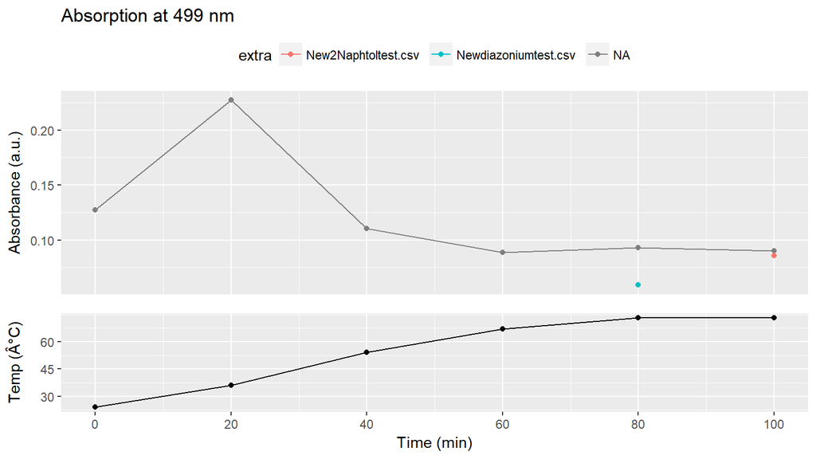

```r
g1 <- specs170929 %>%
  filter(nm == 499) %>%
  ggplot(aes(time, A, color = extra)) +
  geom_point() +
  geom_line() +
  theme(legend.position = "top", axis.text.x = element_blank(), axis.title.x = element_blank(), axis.ticks.x = element_blank()) +
  labs(y = "Absorbance (a.u.)") +
  scale_x_continuous(breaks = seq(0, 100, 20)) +
  labs(title = "Absorption at 499 nm")

g2 <- specs170929 %>%
  ggplot(aes(time, temp)) +
  geom_point() +
  geom_line() +
  labs(x = "Time (min)", y = "Temp (Â°C)") +
  scale_x_continuous(breaks = seq(0, 100, 20)) +
  scale_y_continuous(breaks = c(30, 45, 60))

cowplot::plot_grid(g1, g2, align = "v", ncol = 1, rel_heights = c(2,1))
```

```r
ggsave("../figs/20171020_UV-Vis_2.png", width = 16, height = 9, dpi = 300, units = "cm")
```

# 20170929 Gr-NH2 production with monitoring diazonium concentration

Following the partially succesful graphene production for Radisurf we wish to make a new production in the same way. However, this time the diazonium concentration will be monitored using UV-Vis spectroscopy (see 20170915) and the graphene will be freeze-dried in smaller batches to ensure that a fine powder is obtained.

## Protocol

```r
library(units)
V = set_units(1500, mL) # Volume of 0.1 M H2SO4 to be used
C_diazo = set_units(2, mmol/L)
C_naphtol = set_units(3, mmol/L)
V_naphtol = set_units(30, mL)

M_nitro = set_units(202.64, mg/mmol) # 4-Nitrophenethylamine hydrochloride
M_nitrite = set_units(69.00, mg/mmol) # NaNO2
M_naphtol = set_units(144.17, mg/mmol) # 2-Naphtol

n_nitro = V * C_diazo
n_nitrite = n_nitro * 2
n_naphtol = V_naphtol * C_naphtol # enough to make 15 samples of 2 mL

m_nitro = n_nitro * M_nitro
m_nitrite = n_nitrite * M_nitrite
m_naphtol = n_naphtol * M_naphtol

C_dye = set_units(C_diazo * set_units(2, mL) / set_units(4, mL), mmol/L)
```

### Preparing solutions

First 1 L 1.0 M H<sub>2</sub>SO<sub>4</sub> is made by mixing 55 mL conc. H<sub>2</sub>SO<sub>4</sub> with 962 mL H<sub>2</sub>O. From this 150 mL is diluted to 1500 mL to produce a 0.1 M H<sub>2</sub>SO<sub>4</sub>.

The 2 mmol/L 4-(2-aminoethyl)benzenediazonium solution is generated *in-situ* by mixing 1500 mL 0.1 M H<sub>2</sub>SO<sub>4</sub> with 607.92 mg 4-Nitrophenethylamine hydrochloride (3 mmol) and 414 mg NaNO<sub>2</sub> (6 mmol). This is stirred for 15 min.

A 3 mmol/L solution of 2-Naphtol is made by dissolving 12.9753 mg mg 2-Naphtol in 6 mL 10 % NaOH and 24 mL H<sub>2</sub>O.

Samples for UV-Vis can then be made easily by mixing 2 mL 3 mmol/L 2-Naphtol solution with 2 mL 2 mmol/L diazonium-solution to obtain a solution of the azo-dye (max conc. obtained is 1 mmol/L).

### Gr-NH<sub>2</sub> exfoliation

The electrochemical exfoliation of functionalised graphene will be done by positioning and 8x15 cm<sup>2</sup> graphite foil between two large stainless steel electrodes and applying 10 V for 1 hour or more. Weigh the foil before electrolysis.

2 mL samples will be extracted with a syringe and put into the 2-Naphtol solution through a filter (to remove any graphite) every 10 minutes. At these points the temperature should also be noted.

The exfoliated graphene and remaining graphite foil is collected and washed with water and acetonitrile. The graphene is ultrasonicated in DMF and left overnight for graphite to sediment.

The upper 95 % of the solution is collected and centrifuged to collect most of the graphene. It is then ultrasonicated in water and freeze-dried.

## Journal

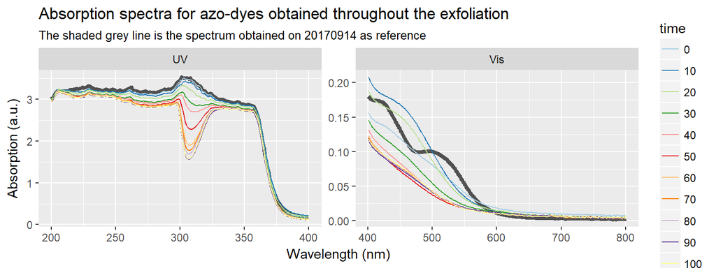

```r
data170929 <- read_csv('../data/raw_data/electrochemistry/20170929_Gr-NH2_exfoliation.csv')
path <- "../data/raw_data/uvvis/170929 Gr-NH2 production/"
specs170929 <- tibble(files = list.files(path = path, pattern = "*.csv")) %>%
  mutate(time = stringr::str_extract(files, "^[:digit:]*") %>% as.numeric()) %>%
  mutate(data = map(paste0(path, files), read_delim, delim = ";", skip = 1)) %>%
  left_join(data170929, by = "time") %>%
  unnest() %>%
  mutate(region = ifelse(nm > 400, "Vis", "UV"))

refspec <- read_delim('../data/raw_data/uvvis/20170915 Azodye/Azo-dye 1-0.csv', delim = ";", skip = 1) %>%
  mutate(region = ifelse(nm > 400, "Vis", "UV"))

specs170929 %>%
  mutate(time = as.factor(time)) %>%
  ggplot() +
  geom_line(data = refspec, aes(nm, A), size = 1.5, alpha = 0.66) +
  geom_line(aes(nm, A, color = time)) +
  scale_color_brewer(palette = "Paired") +
  facet_wrap(~region, scales = "free") +
  labs(x = "Wavelength (nm)", y = "Absorption (a.u.)", title = "Absorption spectra for azo-dyes obtained throughout the exfoliation", subtitle = "The shaded grey line is the spectrum obtained on 20170914 as reference")
```

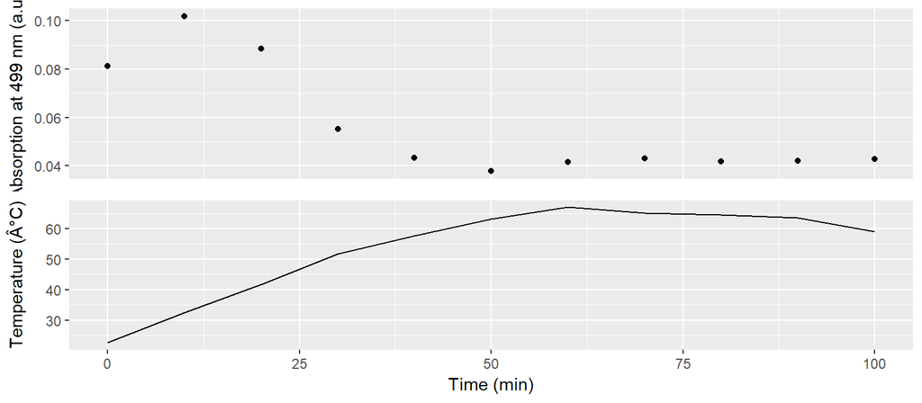

```r
g1 <- specs170929 %>%
  filter(nm == 499) %>%
  ggplot(aes(time, A)) +
  geom_point() +
  theme(axis.text.x = element_blank(), axis.title.x = element_blank(), axis.ticks.x = element_blank()) +
  labs(y = "Absorption at 499 nm (a.u.)")

g2 <- specs170929 %>%
  filter(nm == 499) %>%
  ggplot(aes(time, temp)) +
  geom_line() +
  labs(x = "Time (min)", y = "Temperature (Â°C)")

cowplot::plot_grid(g1, g2, ncol = 1, align = "v", rel_heights = c(1,1.1))
```

The unexfoliated graphite weighed 1.34 g, meaning that a total of 5.74 g was exfoliated. The exfoliated product was washed with water, acetonitrile and water, before being ultrasonicated in 575 mL DMF (ca. 1 g/100 mL) for 45 minutes and left to settle overnight.

100 mL batches of this solution was attempted freeze-dried in several ways:

- With and without aluminum foil used as cover after freezing in LiN
- Spinning the bottle while freezing to create a larger surface area
- Keeping the flask in a -20 Â°C bath while freezedrying.

All attempts were failures, as the liquid water either quickly melted, or did not properly sublimate in a decent time.

A small amount of graphene solution was filtered on 0.45 Î¼m nylon membrane, and the pH of the water measured to approx. 3.90. An acidic aqueous solution might have a lower freezing-point, which could cause problems with the freeze-drying process. Since the samples have been ultrasonicated, a furhter washing procedure is difficult at this step. For this reason a new batch will be produced instead.

## Conclusion and outlook

The production of graphene appeared succesful. It was difficult to monitor the diazonium-concentration using the absorption method, since a spectrum with different peaks was obtained. It might be possible to resolve this by keeping the samples in dark after injecting the diazonium solution, and remembering to gently heat the samples to facilitate reaction, after mixing the 2-Naphtol and the diazonium salt.

The freeze-drying procedure is causing problems on this scale, but it might be due to an insufficient washing-procedure. Next time the entire product will be suspended in clean water several times and the pH of the washing water tested to ensure a neutral solution. It will probably also be necessary to measure the pH after ultrasonication in water, to ensure that acid is not released from between the graphene layers.

To summarise the steps that need to be different in the next production run:

- Careful treatment of the extracted samples for absorption. Heat them gently (which temperature?) for a few minutes and keep in dark until measuring absorbance.
- Extensive washing of the graphene. Previously more water was just run through the filtration setup, but this time the exfoliate should probably be suspended in clean water and refiltered several times. Measure the pH of the filtrate.
- Freeze-drying (how large batches can be made?) - use a rotation-evaporator for the freezing procedure to freeze as a ‘shell’ and experiment with insulating the flask using paper and aluminum foil.

# 20170915 Azo-coupling of diazonium compounds

In the production of functionalised graphene it would be nice to assess that the diazonium compound is continously present. This was previously attempted using electrochemistry, but was not succesful due to very low concentrations.

Another possibility is to use the diazonium compound to make an azo-coupling with 2-Naphtol. This should produce a very colorful dye, which should be easy to measure concentration of using UV-Vis absorption spectroscopy.

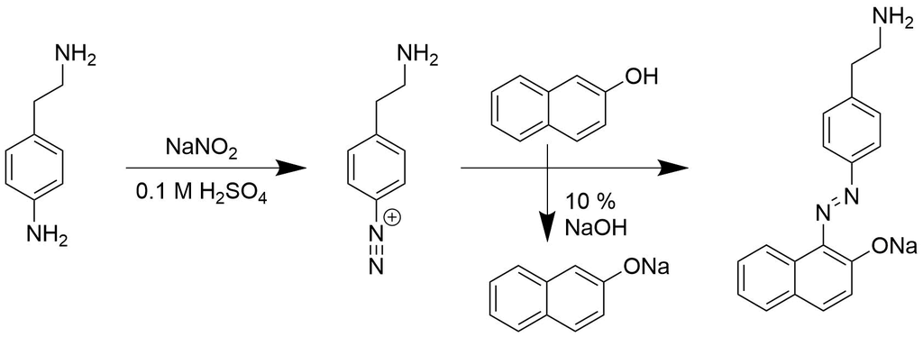

```r
knitr::include_graphics(path = "figs/azo-coupling.png")
```

## Protocol

```r
library(units)
V = set_units(10, mL) # Volume of 0.1 M H2SO4 to be used
C_diazo = set_units(2, mmol/L)

M_nitro = set_units(202.64, mg/mmol) # 4-Nitrophenethylamine hydrochloride
M_nitrite = set_units(69.00, mg/mmol) # NaNO2
M_naphtol = set_units(144.17, mg/mmol) # 2-Naphtol

n_nitro = V * C_diazo
n_nitrite = n_nitro * 1.5
n_naphtol = n_nitro * 1.5

m_nitro = n_nitro * M_nitro
m_nitrite = n_nitrite * M_nitrite
m_naphtol = n_naphtol * M_naphtol

C_dye = set_units(C_diazo * set_units(2, mL) / set_units(4, mL), mmol/L)
```

Initially the diazonium compound is formed by mixing 10 mL 0.1 M H<sub>2</sub>SO<sub>4</sub> with 4.0528 mg 4-Nitrophenethylamine hydrochloride (0.02 mmol) and 2.07 mg NaNO<sub>2</sub> (0.03 mmol). This is stirred for 15 min. The 2-Naphtol solution is made by mixing 4.3251 mg 2-Napthol (0.03 mmol) in 2 mL 10 % sodium hydroxide and 8 mL water

2 mL of the diazonium-solution is then added to 2 mL of the 2-Naphtol solution. This should form an orange-red dye upon heating. The final concentration of the dye is 1 mmol/L.

## Journal

The experiment was performed as described and upon mixing of the diazonium-compound and 2-Naphtol a red-orange solution formed immediately. This was heated using hot water for 5 min before measuring the absorption spectra.

## Results and discussion

UV-Vis absorption spectra were acquired between 200 and 800 nm. The data is first loaded into R.

```r
path <- "../data/raw_data/uvvis/20170915 Azodye/"
data170915 <- tibble(file = list.files(path = path, pattern = "*.csv")) %>%
  mutate(data = map(paste0(path,file), read_delim, delim = ";", skip = 1)) %>%
  mutate(name = stringr::str_extract(file, pattern = "^[\\sa-zA-Z0-9_-]*")) %>%
  unnest() %>%
  mutate(region = ifelse(nm > 400, "Visible", "UV"))
```

We can plot each absorption spectrum. From this we can see that, as expected, all compounds adsorb light in the ultraviolet region, but it is only the synthesized azo-dye that has any significant adsorption in the visible range.

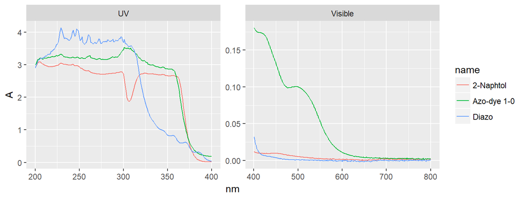

```r
data170915 %>%
  filter(name %in% c("2-Naphtol", "Azo-dye 1-0", "Diazo")) %>%
  ggplot(aes(nm, A, color = name)) +
  geom_line() +
  facet_wrap(~region, ncol = 2, scales = "free")
```

```r
ggsave("../figs/20170904_UVVis_compounds.png", width = 16, height = 6, units = "cm", dpi = 300)
```

Data has also been obtained for a series of dilutions of the azo-dye to make a calibration curve. The numbers in the legend indicate the dilution factor (i.e 1 to 0, 1 to 2 etc.)

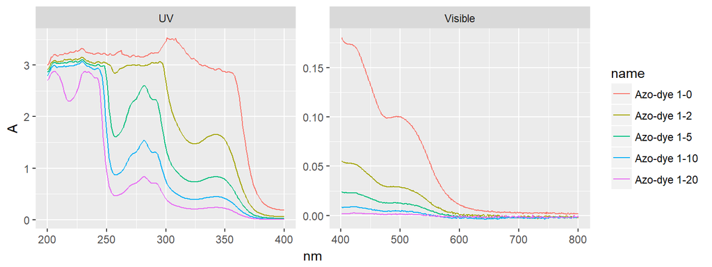

```r
data170915 %>%
  filter(stringr::str_detect(name, "^(Azo)")) %>%
  mutate(name = forcats::fct_reorder(name, A, .desc = TRUE)) %>%
  ggplot(aes(nm, A, color = name)) +
  geom_line() +
  facet_wrap(~region, ncol = 2, scales = "free")
```

The peak at 499 nm is used to make a calibration curve and to calculate an extinction coefficient for the azo-dye.

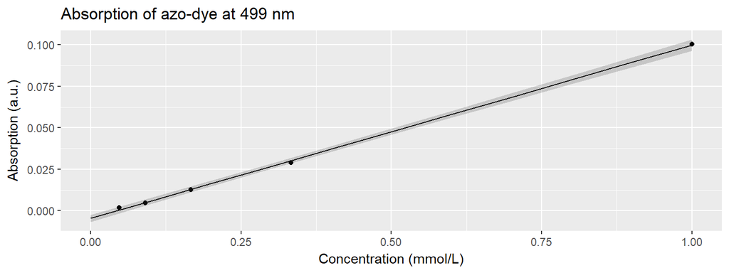

```r
data170915_cal <- data170915 %>%
  filter(stringr::str_detect(name, "^(Azo)"), nm == 499) %>%
  mutate(dilution = stringr::str_extract(name, "\\d-[\\d]+")) %>%
  separate(dilution, c("start", "dilution"), convert = TRUE) %>%
  mutate(C = start / (dilution+start))

# Fit a linear model to the data
fit170915 <- lm(A ~ C, data = data170915_cal)

new_C <- tibble(C = seq(0, 1, 0.1))
fitted170915 <- cbind(new_C, predict(fit170915, interval = "confidence", newdata = new_C))

data170915_cal %>%
  ggplot() +
  geom_point(aes(C, A)) +
  geom_line(data = fitted170915, aes(C, fit)) +
  geom_ribbon(data = fitted170915, aes(x = C, ymin = lwr, ymax = upr), alpha = 0.2) +
  labs(title = "Absorption of azo-dye at 499 nm", x = "Concentration (mmol/L)", y = "Absorption (a.u.)")
```

```r
ggsave("../figs/20170904_UVVis_dilution.png", width = 16, height = 4, units = "cm", dpi = 300)
```

The absorption coefficient at 499 nm becomes 0.104 Â± 0.005 mM<sup>-1</sup> cm<sup>-1</sup>. Note that this is for the azo-dye, and the concentration of the diazonium is halved during the production of the dye. In reality, relative concentrations within a single experiment are probably most interesting.

## Conclusion and outlook

Based on this experiment it should be possible to easily monitor the concentration of diazonium salt during exfoliation of graphite. 2 mL samples of the exfoliation solution can be extracted at regular intervals, filtered for graphite and then injected directly into a solution of sodium naphthalen-2-olate. From this the adsorption spectrum will directly tell to what degree the diazonium compound has degraded.

# 20170904 Gr-NH2 production for Radisurf

Following the initial tests in the new graphene production setup a batch of amine-functionalised graphene will be produced. Radisurf will attempt surface-polymerisation on the graphene and embed it in a silicone matrix.

## Protocol

```r
library(units)
V = set_units(1500, mL) # Volume of 0.1 M H2SO4 to be used
C_diazo = set_units(2, mmol/L)

M_nitro = set_units(202.64, mg/mmol) # 4-Nitrophenethylamine hydrochloride
M_nitrite = set_units(69.00, mg/mmol) # NaNO2

n_nitro = V * C_diazo
n_nitrite = n_nitro * 2

m_nitro = n_nitro * M_nitro
m_nitrite = n_nitrite * M_nitrite
```

The 2 mmol/L 4-(2-aminoethyl)benzenediazonium solution is generated in-situ by mixing 1500 mL 0.1 M H<sub>2</sub>SO<sub>4</sub> with 607.92 mg 4-Nitrophenethylamine hydrochloride (3 mmol) and 414 mg NaNO<sub>2</sub> (6 mmol). This is stirred for 15 min. The presence of diazonium-compound is confirmed by dissolving a small amount of ferrocene in DMF and adding some of the solution to check for a green color.

To test the stability of the diazonium-compound during the electrochemical exfoliation Cyclic Voltammetry will be used periodically under non-grafting conditions (diazonium concentation < 0.1 mM). A blank CV will be recorded in 9.5 mL 0.1 M H<sub>2</sub>SO<sub>4</sub>, 0.5 mL electrolyte solution will be added and a CV recorded for one reductive sweep (range?) using a glassy carbon microelectrode, Pt counter electrode and SCE reference electrode. The temperature should be recorded when extracting samples.

The electrochemical exfoliation of functionalised graphene will be done by positioning and 8x15 cm<sup>2</sup> graphite foil between two large stainless steel electrodes and applying 10 V for 1 hour (more if the indication is that the diazonium-salt is still active and the graphite is not fully exfoliated). Weigh the foil before electrolysis

The exfoliated graphene and remaining graphite foil is collected and washed with water and acetonitrile. The graphene is ultrasonicated in DMF and left overnight for graphite to sediment. The upper 95 % of the solution is collected and centrifuged to collect most of the graphene - the remaining part is collected by filtration on 0.45 um nylon membrane filters. All graphene is then ultrasonicated in water and freeze-dried.

## Journal

The experiment was conducted as described in the protocol. The mass of the graphite electrode was 7.0990 g. The exfoliation was continued for 90 minutes and a ferrocene-test at this point gave a green solution, indicating that diazonium-compound was still present.

The product was dried at 50 Â°C under vacuum for 2 hours, which was insufficient to completely dry the sample (mass of product at this stage = 279.5 g - 243.9 g = 35.6 g). The mass of the remaining graphite electrode was 1.8904 g, meaning that 5.2086 g graphite was exfoliated in 90 min.

```r
exp170904 <- tibble(
  t = c(0, 15, 30, 45, 60, 90),
  sample_collected = c(TRUE, TRUE, TRUE, TRUE, TRUE, FALSE),
  temp = c(23, 38, 51, 62, 67, 69),
  current = c(17.2, 19.4, 19.7, 19.9, 19.0, 12.7),
  voltage = rep(10, 6))

knitr::kable(exp170904, col.names = c('Time (min)', 'Sample collected', 'Temp. Â°C', 'Current (A)', 'Voltage (V)'))
```

| Time (min) | Sample collected | Temp. Â°C | Current (A) | Voltage (V) |
| --- | --- | --- | --- | --- |
| 0 | TRUE | 23 | 17.2 | 10 |
| 15 | TRUE | 38 | 19.4 | 10 |
| 30 | TRUE | 51 | 19.7 | 10 |
| 45 | TRUE | 62 | 19.9 | 10 |
| 60 | TRUE | 67 | 19.0 | 10 |
| 90 | FALSE | 69 | 12.7 | 10 |

The exfoliated graphite was then ultrasonicated in 400 mL DMF for 1 hour and left to stand for 2 days (1 was probably enough) to allow residual graphite to sedimentate. The solution was then centrifuged at 4000 rpm for 1 hour and the pellet was collected in water. The remaining graphene solution in DMF was filtered on 0.45 um nylon membrane and the solid product collected in water. The entire graphene solution in water was put in a 500 mL roundbottomed flask and ultrasonicated for 30 min. This was then frozen using liquid nitrogen (LiN) and put on the freeze-drier. Later the same day it was realized that the LiN had not frozen the suspension completely, so instead it was frozen overnight in an ordinary freezer and put on the freeze-drier over a weekend, after which it was completely dry.

## Results and discussion

### Following the diazonium-concentration during functionalisation

An attempt was made to monitor the concentration of diazonium compound during the reaction. This is tricky because it must be done at non-grafting concentrations, meaning the diazonium-concentration should be below 0.1 mM (= very low signal). Blank CVs and CVs in diazonium solution at different times during the experiment is displayed below.

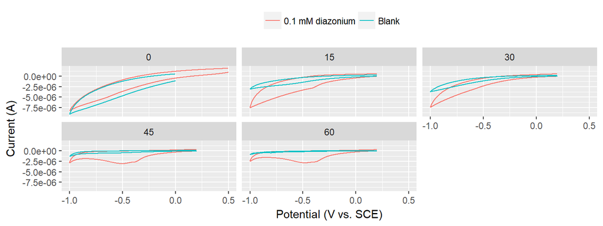

```r
path <- "../data/raw_data/electrochemistry/20170904_Gr-NH2_prod_for_Radisurf/"
electrochem170904 <- tibble(filename = list.files(path = path, pattern = "*.txt")) %>%
  filter(grepl("^((\\d)|(CV2)|(I))", filename)) %>%
  mutate(sample = stringr::str_extract(filename, "^(\\d){2}"), sample = as.numeric(ifelse(is.na(sample), 0, sample))) %>%
  mutate(sol = stringr::str_extract(filename, "(blank)"), sol = ifelse(is.na(sol), "0.1 mM diazonium", "Blank")) %>%
  mutate(data = map(paste0(path, filename), read_csv, col_names = c('pot', 'cur'))) %>%
  unnest()

electrochem170904 %>%
  ggplot(aes(pot, cur, color = sol)) +
  geom_path() +
  facet_wrap(~sample) +
  labs(x = "Potential (V vs. SCE)", y = "Current (A)") +
  theme(legend.position = "top", legend.title = element_blank())
```

```r
ggsave("../figs/20170904_electrochem_exfoliation.png", width = 16, height = 12, units = "cm", dpi = 300)
```

### Yield and quality

After freeze-drying the dry graphene product was collected. A total of 3.4196 g was obtained in the process, giving a yield of 65.7 %. The graphene has collected in a mix of denser chunks and thin sheets, and not in as fine a powder as expected. This is probably due to the slower cooling in the freezer, rather than a rapid freeze in LiN just after ultrasonication. However, the product still appears to disperse rather easily upon ultrasonication in solvents.

#### Raman spectroscopy

Raman microscopy was performed on 20170920. The samples was deposited on SiO2 from graphene dispersed in DMF and deposited using the self-assembly method. Two maps were obtained. The first at 33 % intensite (100 % in Wire) with a short acquisition time, and the second at a lower intensity (10 % in Wire) with a longer acquisition time.

Representative Raman spectra and the corresponding curve fit is shown below.

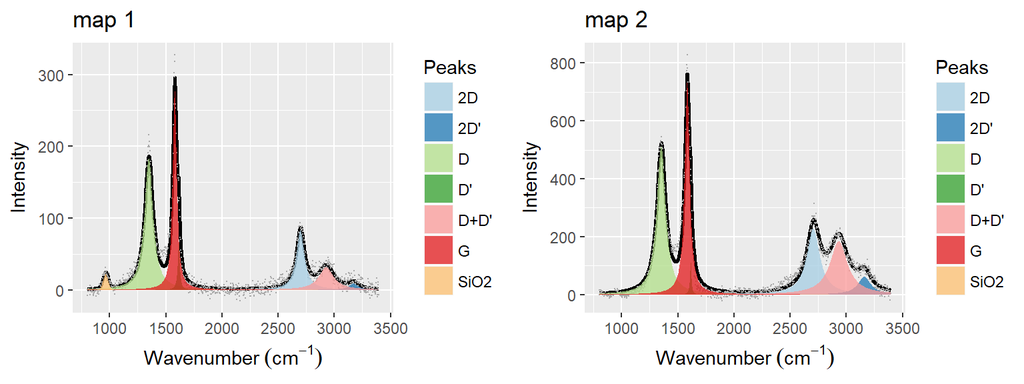

```r
library(osctools)
ramanspecs170920 <- tibble(data = c('../data/derived_data/raman/20170920_Gr-NH2_for_Radisurf/20170920 Gr-NH for Radisurf map 1_1691__X_19.5__Y_-16__Time_181.txt', '../data/derived_data/raman/20170920_Gr-NH2_for_Radisurf/20170920 Gr-NH for Radisurf map 2_697__X_7.65858__Y_-11.065__Time_703.txt'),
  fits = c('../data/derived_data/raman/20170920_Gr-NH2_for_Radisurf/20170920_curvedata_map 1_1691__X_19.5__Y_-16__Time_181.txt','../data/derived_data/raman/20170920_Gr-NH2_for_Radisurf/20170920_curvecata_map 2_697__X_7.65858__Y_-11.065__Time_703.txt')) %>%
  mutate(names = stringr::str_extract(data, "map\\s\\d")) %>%
  mutate(plots = map2(data, fits, gr_cf_fit_plot)) %>%
  mutate(plots = map2(plots, names, function(x, y) {x + labs(title = y)}))

g_specs <- gridExtra::arrangeGrob(grobs = ramanspecs170920$plots, ncol = 2)
ggsave(filename = '../figs/20170904_GrNH2_raman.png', plot = g_specs, width = 16, height = 6, units = "cm", dpi = 300)
plot(g_specs)
```

By mapping over a surface it is reavealed that even though the G intensity varies a lot across the surface, mainly due to differences in thickness, the defect density across the surface is pretty uniform. The defect density varies most on `map 2`, which was recorded at a lower laser intensity. This means that `map 1` might be damaged by the laser during acquisition.

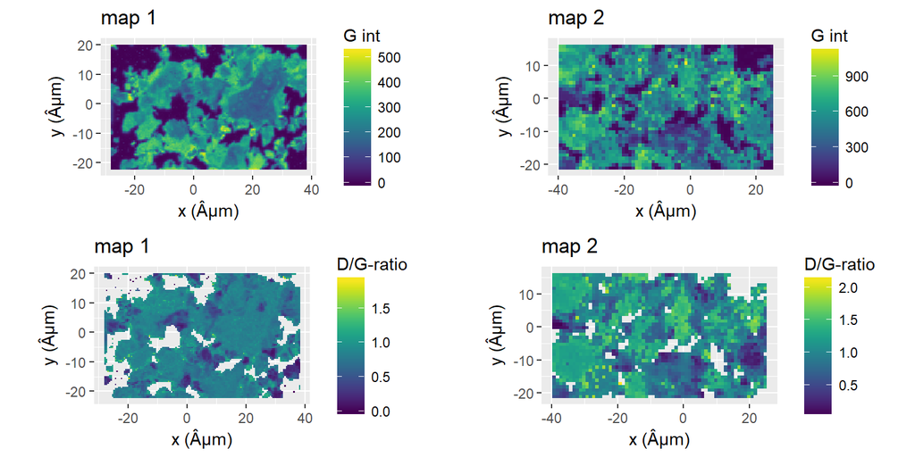

```r
raman170920 <- tibble(
  folders = c('../data/derived_data/raman/20170920_Gr-NH2_for_Radisurf/20170920 Gr-NH for Radisurf map 1/','../data/derived_data/raman/20170920_Gr-NH2_for_Radisurf/20170920 Gr-NH for Radisurf map 2/'),
  names = stringr::str_extract(folders, "map\\s\\d")
  ) %>%
  mutate(data = map(folders, raman_curvefit_read)) %>%
  unnest()

plot_map <- function(df, feature) {
  feature <- enquo(feature)
  name <- unique(df$names)[1]
  df %>%
    select(x, y, value = !! feature) %>%
    ggplot(aes(x, y, fill = value)) +
      geom_raster() +
      coord_equal() +
    labs(x = "x (Âµm)", y = "y (Âµm)", fill = quo_name(feature), title = name) +
    viridis::scale_fill_viridis()
}

g1 <- raman170920 %>%
  filter(names == "map 1") %>%
  plot_map(`G int`)

g2 <- raman170920 %>%
  filter(names == "map 2") %>%
  plot_map(`G int`)

g3 <- raman170920 %>%
  filter(names == "map 1") %>%
  filter(`G int` > 0.05 * max(`G int`)) %>%
  plot_map(`D/G-ratio`)

g4 <- raman170920 %>%
  filter(names == "map 2") %>%
  filter(`G int` > 0.05 * max(`G int`)) %>%
  plot_map(`D/G-ratio`)

gridExtra::grid.arrange(g1, g2, g3, g4, ncol = 2)
```

#### XPS

XPS data was acquired on the freeze-dried powder in two different spots. The summary of the data is presented below.

```r
xpsres170920 <- read_tsv('../data/derived_data/xps/20170920_Gr-NH2_for_Radisurf/20170920_xps_ratios.txt', skip = 2)

xpsres170920 %>%
  select(ends_with("%")) %>%
  rename_all(
      funs(
        stringr::str_extract(., "^[a-zA-Z0-9\\s]*")
      )
  ) %>%
  gather(key = 'element', value = 'value') %>%
  group_by(element) %>%
  summarise(m = mean(value), sd = sd(value)) %>%
  mutate_at(c('m', 'sd'), round, digits = 2) %>%
  knitr::kable(col.names = c('Element', 'Mean', 'Std. dev.'))
```

| Element | Mean | Std. dev. |
| --- | --- | --- |
| C 1s | 79.29 | 1.25 |
| Cl 2p | 0.16 | 0.03 |
| N 1s | 0.80 | 0.01 |
| O 1s | 18.62 | 1.19 |
| S 2p | 0.35 | 0.05 |
| Si 2p | 0.78 | 0.05 |

Nitrogen was clearly introduced in the graphene, as would be expected for amine-functionalised graphene. Some of the N might also be from azo-coupled diazonium salt. HR-XPS of the N 1s peak might be able to give more information.

In this data a sulphur-peak was also clearly observed at approx. 168.5 eV. A thiol whould normally be observed at 164 eV, so this suggests that we have -SO<sub>4</sub> bound to the surface, as would probably be expected from the oxidative exfoliation in sulphuric acid. Andreas did not observed this in his experiments. It might be possible to anneal the graphene and get rid of this.

#### ATR-IR

Seeing that XPS revealed nitrogen I was tempted to do ATR-IR on some of the powder.

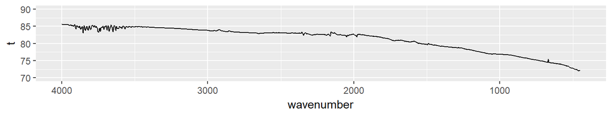

```r
ir170920 <- read_delim('../data/raw_data/ir/20170922_ATR-IR_Gr-NH2/Administrator 1001_148.csv', delim = ";", skip = 2, col_names = c("wavenumber", "t"), locale = locale(decimal_mark = ","))

ir170920 %>%
  ggplot(aes(wavenumber, t)) +
  geom_line() +
  scale_x_reverse() +
  coord_cartesian(ylim = c(70, 90))
```

```r
ggsave('../figs/20170904_ATRIR_Gr_NH2.png', width = 16, height = 4, units = "cm", dpi = 300)
```

However, it seems that concentration is too low to observed any amine-groups. Maybe it could be possible to deposit the graphene on a reflective surface such as gold and do PM-IRRAS.

## Conclusion and outlook

Based on XPS-measurements it seems that the amine-functionalisation was succesful. The electrochemical approach was not useful for following the diazonium-concentration.

The freeze-drying procedure was only partly succesfull, since a product that was too compact was obtained. Freeze-drying small amounts (perhaps 100 mL) is probably the way to go.

# 20170809 Functionalised graphene by oxidative exfoliation

```r
library(units)
V = set_units(200, mL) # Volume of 0.1 M H2SO4 to be used
C_diazo = set_units(2, mmol/L)

M_nitro = set_units(202.64, mg/mmol) # 4-Nitrophenethylamine hydrochloride
M_nitrite = set_units(69.00, mg/mmol) # NaNO2

n_nitro = V * C_diazo
n_nitrite = n_nitro * 2

m_nitro = n_nitro * M_nitro
m_nitrite = n_nitrite * M_nitrite
```

## Protocol

This production method is inspired by the work by Belanger and co-workers.<sup>2</sup>

### In-situ generation of 2 mmol/L 4-(2-aminoethyl)benzenediazonium solution

200 mL 0.1 M H<sub>2</sub>SO<sub>4</sub> is mixed with 81.056 mg 4-Nitrophenethylamine hydrochloride (0.4 mmol) and 55.2 mg NaNO<sub>2</sub> (0.8 mmol) and stirred for 15 min.

A small amount of ferrocene is dissolved in 1 mL solution to confirm that the diazonium compound has been formed (green color).

## Exfoliation of functionalised graphene flakes

A 2-electrode setup is made with 100 cm<sup>2</sup> 0.5 mm graphite foil (cut into four 5x5 cm<sup>2</sup> pieces) as the anode (+) and a sheet of stainless steel as the cathode (-) in a tall 400 mL beaker. **Consider putting a piece of filter paper between the electrodes to prevent exfoliated graphene contacting the cathode**. The freshly made diazonium-solution is poured into the beaker and the graphite exfoliated at 10 V for 1 hour (longer if the foil is not properly exfoliated at this stage). This was done in our grounded cage, and the ground terminal of the power supply was connected to the cage.

Wash the remaning graphite foil with water and dry it (for yield calculation). The flakes are then collected with vacuum filtration and washed with water and acetonitrile. Ultrasonicate into DMF to disperse the graphene flakes. Leave overnight to sedimentate remaning graphite. Centrifuge the top part of the DMF solution at high speed for 1 hour to sedimentate the remaning graphene. Remove DMF and ultrasonicate in water. Freeze-dry the aqueous solution to obtain graphene powder.

## Journal

The experiment was performed as described in the protocol. Graphite foil (for four 5x5 cm pieces, 5.8150 g total mass) was used as the anode. 0.1 M H2SO4 was made by mixing 1.4 mL conc. H<sub>2</sub>SO<sub>4</sub> and diluting until 250 mL H<sub>2</sub>O.

The diazonium compound formed as described. Tested against ferrocene in DMF and gave a green solution.

The graphite foil was electrolysed for 3 hr + 20 min. Solution got quite hot, so a lot evaporated = lower water level. Generally the current drawn was approx. 4 A.

After the electrolysis another ferrocene test was made. A green color indicated that diazonium-compound was still present in the solution despite the high temperatures reached.

Electrodes were washed and the product filtered, washed with water and acetonitrile. Then ultrasonicated in 250 mL DMF for 30 min and left overnight.

200 mL was decanted the morning after (more could probably have been taking by pipetting off the top layer instead). This was centrifuged at 4000 rpm for 60 min. to collect most of the graphene. The remaining DMF was removed by filtration on 0.45 Âµm nylon membrane filters. All graphene collected was then dispersed in water by ultrasonication.

The dry weight of remaining graphite = 4.4859 g

### New setup

Since the previously mentioned production only allowed for a current of 4 A, we did not fully utilize the maximum capacity of our new power supply (max. 20 A). A new electrochemical cell was constructed as illustrated below. Two large stainless steel plates were placed on either side and used as the cathode, while a graphite foil anode was placed in the middle.

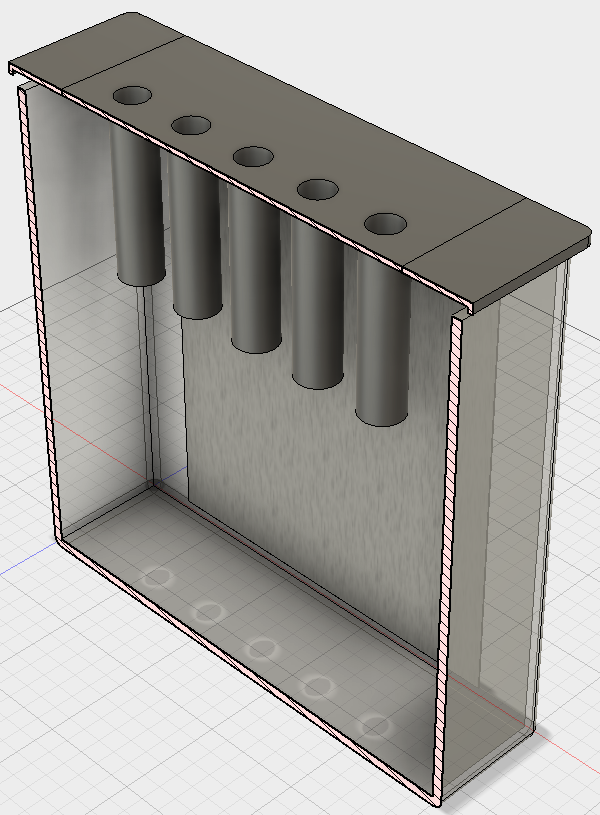

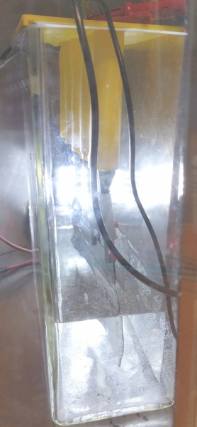

Production in this setup was conducted without the diazonium salt, to confirm that everything worked as expected. 1.5 L 0.1 M H<sub>2</sub>SO<sub>4</sub> was made (8.25 mL H<sub>2</sub>SO<sub>4</sub> diluted to 1.5 L). A 8x15 cm<sup>2</sup> graphite foil (7.0604 g) was used as the anode. This was electrolysed at 10 V for 1 hour (~18-20 A currrent). The exfoliated product was filtrated and washed with water and ethanol. It was then dried in an oven.

After electrolysis 2.7092 g graphite remained (4.3512 g exfoliated in 1 hour). Mass of graphene exfoliated = 292.6 g - 259.6 g = 33 g. However, there is no way that all of this mass is graphene! Lets try to dry it more. (Update on 20170904: Mass recorded to 261.3 g after 2 h at 50 dC in vacuum oven = 1.7 g graphene.)

# References

(1) Kowalczyk, A.; Nowicka, A.; Jurczakowski, R.; Fau, M.; Krolikowska, A.; Stojek, Z. Construction of Dna Biosensor at Glassy Carbon Surface Modified with 4-Aminoethylbenzenediazonium Salt. *Biosensors and Bioelectronics* **2011**, *26* (5), 2506–2512 DOI: https://doi.org/10.1016/j.bios.2010.10.046.

(2) Ossonon, B. D.; Bélanger, D. Functionalization of Graphene Sheets by the Diazonium Chemistry During Electrochemical Exfoliation of Graphite. *Carbon* **2017**, *111*, 83–93 DOI: 10.1016/j.carbon.2016.09.063.

Emil Tveden Bjerglund

Last updated: 2017-10-28